# (presque) Tout ce dont votre package a besoin

Joseph Barbier - *PyCon2025*

## A propos

*Joseph*

barbierjoseph.com

ysunflower.com

Consulting

Open source

Data(viz)

## Questions

Qui ne sait pas du tout ce qu’est un package Python ?

Qui a déjà créé un package Python ?

Qui contribue à des packages Python open source ?

Qui a déjà mis sur PyPI un package Python ?

## TLDR: package Python

```python
def my_super_cool_function(arg):
    if arg == "cool":
        something = 123
    else:
        ...

    ...

    return something
```

[figure not shown]

[figure not shown]

Facilement **distribuable** et donc **reutilisable** !

## Le bon package et le mauvais package

[figure not shown]

Un bon package **c’est pas (uniquement) une question de code**.

- facile à installer ?
- facile à comprendre ?
- facile à utiliser ?
- facile à développer ?

## Sommaire

### Votre package a besoin de ces 3 choses, **la dernière va vous surprendre 😱** !

- `pyproject.toml` et gestion des dépendances
- Tester dans les meilleures conditions
- Créer la meilleure documentation

# Gestion des dépendances

## *one ring **file** to rule them all*

Un package ça se décompose en :

- du code Python
- des méta données
  - un nom, une description, des auteur.e.s
  - des dépendances (numpy, pandas, etc)
  - une license
  - …

✨`pyproject.toml`✨

## *one ring **file** to rule them all*

`pyproject.toml` + [uv](https://docs.astral.sh/uv/) = <3

[figure not shown]

## Gestion des dépendances

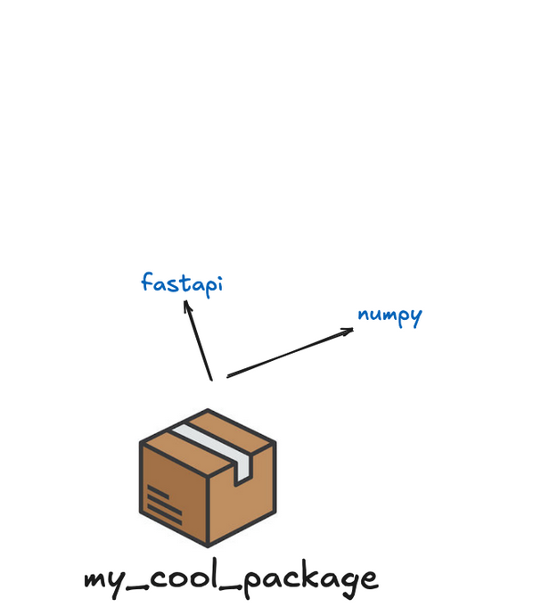

## Gestion des dépendances

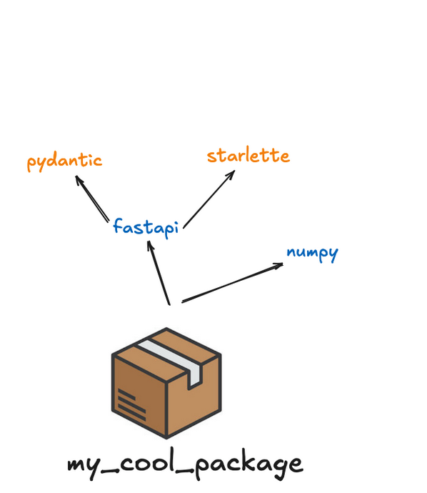

## Gestion des dépendances

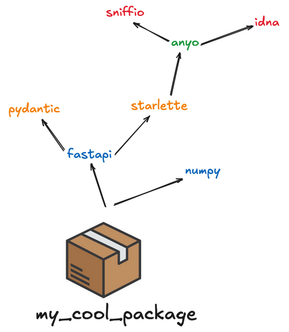

## Gestion des dépendances

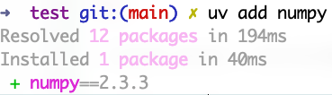

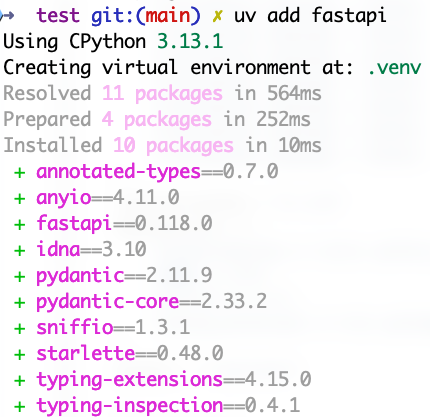

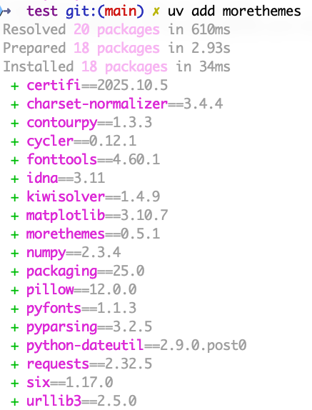

## Gestion des dépendances

- open source → être convenient

`numpy>=2.1.0`

- closed source → restreindre autant que possible

`numpy==2.1.3`

# Tester son code

## Tester son code

[figure not shown]

Tester son code ça veut dire quoi ?

- vérifier que le code **n’a pas d’erreur**
- vérifier que le code **fait ce que je pense**
- vérifier que le code **fonctionne dans différents scénarios**
- vérifier que le code **fonctionne dans différents environnements**

Il suffit de le faire tourner!

Il suffit de le faire tourner?

## Comment (et quoi) tester

- trust yourself
  - ❌ pas d’erreur
  - ❌ fait ce que je pense
  - ❌ différents scénarios
  - ❌ différents environnements
- lancer un exemple d’utilisation
  - ✅ pas d’erreur
  - ❓ fait ce que je pense
  - ❌ différents scénarios
  - ❌ différents environnements
- écrire des tests unitaires
  - ✅ pas d’erreur
  - ✅ fait ce que je pense
  - ✅ différents scénarios
  - ❌ différents environnements
- git push ✅

[figure not shown]

## Github actions

Scrits (yaml) qui se déclenchent dans certaines conditions

- push
- pull requests
- tous les jours à minuit
- …

→ faire tourner les tests unitaires

→ sur plusieurs versions de Python (open source ?)

→ sur plusieurs OS

→ **Et cela tout le temps!**

## Github actions

sur plusieurs OS

## Github actions

sur plusieurs OS ???

**Avertissement**

Python est interprété, mais peut se comporter différemment en fonction de l’OS

- noms de fichiers
- chemins
- fichiers temporaires
- permissions
- modules spécifiques

# Documentation

[figure not shown]

## Documentation

**La première (et la seule) chose que les gens verronts**

Pour ça on a besoin de 2 choses:

- Landing page
- Diátaxis framework

## Landing page

- A quoi sert le package?
- Dans quel contexte il s’inscrit (e.g., package Python)
- Exemple usage minimaliste
- Donner envie!

## Landing page

[figure not shown]

## Landing page

[figure not shown]

## Landing page

[figure not shown]

## Landing page

[figure not shown]

## Exemple parfait: `plotnine`

[video not shown]

## Diátaxis framework (**diataxis.fr**)

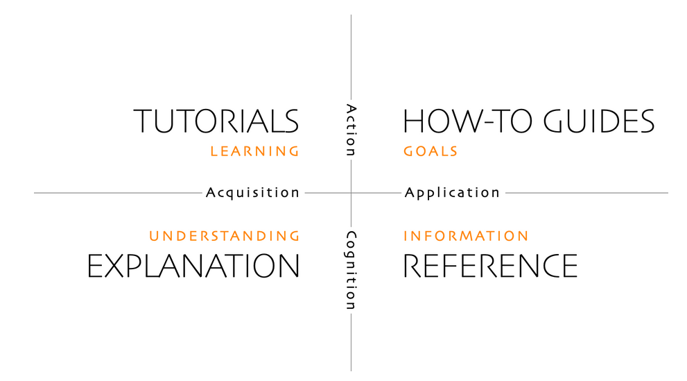

## Aller plus loin

- [github.com/y-sunflower/python-packaging-essentials](https://y-sunflower.github.io/python-packaging-essentials/)
- github.com/y-sunflower/python-package-template
  - des projets open source pour la communauté
  - vous voulez contribuer ? c’est super facile !

Merci !

J’ai dis des choses fausses ?

- venez m’en parler !

J’ai dis des choses pertinentes ?

- venez m’en parler !

Autres ?

- venez me voir !
- linkedin: Joseph Barbier
- mail: `joseph.barbierdarnal@gmail.com`
- slides: [github.com/JosephBARBIERDARNAL/talk](https://github.com/JosephBARBIERDARNAL/talk/tree/main/src/pycon2025)